# Homework 3

STAT 399

DTR

Due: Tuesday 5/12/2020 by 4:30 pm

# Part 0: Getting to know the data

We are grabbing three sets of data to analyze the current Coronavirus situation in the US. We have a time series data, daily reports, and some general statistics about each state.

```r
names(covid.usa.ts)
```

```
##   [1] "UID"            "iso2"           "iso3"           "code3"
##   [5] "FIPS"           "Admin2"         "Province_State" "Country_Region"
##   [9] "Lat"            "Long_"          "Combined_Key"   "1/22/20"
##  [13] "1/23/20"        "1/24/20"        "1/25/20"        "1/26/20"
##  [17] "1/27/20"        "1/28/20"        "1/29/20"        "1/30/20"
##  [21] "1/31/20"        "2/1/20"         "2/2/20"         "2/3/20"
##  [25] "2/4/20"         "2/5/20"         "2/6/20"         "2/7/20"
##  [29] "2/8/20"         "2/9/20"         "2/10/20"        "2/11/20"
##  [33] "2/12/20"        "2/13/20"        "2/14/20"        "2/15/20"
##  [37] "2/16/20"        "2/17/20"        "2/18/20"        "2/19/20"
##  [41] "2/20/20"        "2/21/20"        "2/22/20"        "2/23/20"
##  [45] "2/24/20"        "2/25/20"        "2/26/20"        "2/27/20"
##  [49] "2/28/20"        "2/29/20"        "3/1/20"         "3/2/20"
##  [53] "3/3/20"         "3/4/20"         "3/5/20"         "3/6/20"
##  [57] "3/7/20"         "3/8/20"         "3/9/20"         "3/10/20"
```

[output cut: 17 more lines]

```r
head(covid.usa.daily)
```

```
## # A tibble: 6 x 18
##   Province_State Country_Region Last_Update           Lat  Long_ Confirmed
##   <chr>          <chr>          <dttm>              <dbl>  <dbl>     <dbl>
## 1 Alabama        US             2020-05-08 02:32:36  32.3  -86.9      9046
## 2 Alaska         US             2020-05-08 02:32:36  61.4 -152.        374
## 3 American Samoa US             2020-05-08 02:32:36 -14.3 -170.          0
## 4 Arizona        US             2020-05-08 02:32:36  33.7 -111.       9945
## 5 Arkansas       US             2020-05-08 02:32:36  35.0  -92.4      3703
## 6 California     US             2020-05-08 02:32:36  36.1 -120.      62148
## # ... with 12 more variables: Deaths <dbl>, Recovered <dbl>, Active <dbl>,
## #   FIPS <dbl>, Incident_Rate <dbl>, People_Tested <dbl>,
## #   People_Hospitalized <dbl>, Mortality_Rate <dbl>, UID <dbl>, ISO3 <chr>,
## #   Testing_Rate <dbl>, Hospitalization_Rate <dbl>
```

We see this information is an aggregate of information between April 14th and May 7th as offered in the description.

# Part 1: Wrangling the COVID-19 data

Now that we’ve gotten to see the data a little bit we can now try to wrangle it into a form that we can make some sense out of.

To get the primary keys we’ll write a quick function to test. If all values are unique then it is a key.

```r
primary_keys <- function( data, keysonly = FALSE ){
        if( keysonly ){
                keys <-primary_keys(data)
                return(keys[keys==TRUE])
        }else{
        mclapply(data, function(x){
                return( length(unique(x)) == length(x))
                })
        }
}
```

Covid USA Time Series"

```r
str(primary_keys(covid.usa.ts[,c(1:11)], keysonly=TRUE))
```

```
## List of 2
##  $ UID         : logi TRUE
##  $ Combined_Key: logi TRUE
```

The keys for `covid.usa.ts` are the `UID`, and `Combined_Key`. These two each functionaly determine the rest of the elements.

Covid USA Daily

```r
str(primary_keys(covid.usa.daily, keysonly=TRUE))
```

```
## List of 6
##  $ Province_State: logi TRUE
##  $ Confirmed     : logi TRUE
##  $ Active        : logi TRUE
##  $ FIPS          : logi TRUE
##  $ Mortality_Rate: logi TRUE
##  $ UID           : logi TRUE
```

```r
tmp <- left_join( covid.usa.ts[,1:11], rename( covid.usa.daily, ), by= c( "UID" = "UID" ) )
tmp %>% filter(Province_State.x == Province_State.y) %>%
        select( Province_State.x, Province_State.y )
```

```
## # A tibble: 7 x 2
##   Province_State.x         Province_State.y
##   <chr>                    <chr>
## 1 American Samoa           American Samoa
## 2 Guam                     Guam
## 3 Northern Mariana Islands Northern Mariana Islands
## 4 Puerto Rico              Puerto Rico
## 5 Virgin Islands           Virgin Islands
## 6 Diamond Princess         Diamond Princess
## 7 Grand Princess           Grand Princess
```

The foreign keys between these two tables is the `Province_State` which is in `covid.usa.ts` with the foreign key being in `covid.usa.daily`. The `UID` column does not appear to be a foreign key.

## Aggregating State Level Data

```r
covid.usa.states.ts <- covid.usa.ts %>%
        group_by(Province_State) %>%
        summarize_at( vars(-names(.)[1:6],-names(.)[8:11]) ,sum,na.rm=TRUE )
```

## Combining Data

We’ll use the foreign key `Province_State` to do a left join on these tables.

```r
covid.usa.all <- left_join(covid.usa.daily, covid.usa.states.ts,  by="Province_State")
```

# Part 2: Wrangling the population data

We’d like to bucket the age groups

```r
names(popdata)
```

```
##  [1] "SUMLEV"            "REGION"            "DIVISION"
##  [4] "STATE"             "NAME"              "SEX"
##  [7] "ORIGIN"            "RACE"              "AGE"
## [10] "CENSUS2010POP"     "ESTIMATESBASE2010" "POPESTIMATE2010"
## [13] "POPESTIMATE2011"   "POPESTIMATE2012"   "POPESTIMATE2013"
## [16] "POPESTIMATE2014"   "POPESTIMATE2015"   "POPESTIMATE2016"
## [19] "POPESTIMATE2017"   "POPESTIMATE2018"
```

```r
unique(popdata$AGE)
```

```
##  [1]  0  1  2  3  4  5  6  7  8  9 10 11 12 13 14 15 16 17 18 19 20 21 22 23 24
## [26] 25 26 27 28 29 30 31 32 33 34 35 36 37 38 39 40 41 42 43 44 45 46 47 48 49
## [51] 50 51 52 53 54 55 56 57 58 59 60 61 62 63 64 65 66 67 68 69 70 71 72 73 74
## [76] 75 76 77 78 79 80 81 82 83 84 85
```

Trust, but verify, take a random sample and see that the function worked as expected.

```r
pop.data <- popdata %>%
        mutate(AGE.GRP = case_when(
                (AGE >= 0  & AGE < 6)  ~ "0-5",
                (AGE >= 6  & AGE < 19) ~ "6-18",
                (AGE >= 19 & AGE < 41) ~ "19-40",
                (AGE >= 41 & AGE < 71) ~ "41-70",
                (AGE >= 71)            ~ "71+"
                )
              )

sample_n(pop.data, 50) %>%
        select(AGE,AGE.GRP)
```

```
## # A tibble: 50 x 2
##      AGE AGE.GRP
##    <dbl> <chr>
##  1    76 71+
##  2    50 41-70
##  3    21 19-40
##  4    68 41-70
##  5     4 0-5
##  6    36 19-40
##  7    47 41-70
##  8    31 19-40
##  9     6 6-18
## 10     5 0-5
## # ... with 40 more rows
```

Now to aggregate the population for 2018.

```r
pop.agg <- pop.data %>%
        group_by(NAME, AGE.GRP, SEX) %>%
        select(SUMLEV:AGE,POPESTIMATE2018, AGE.GRP) %>%
        summarize_at( vars(POPESTIMATE2018), sum, na.rm=TRUE) %>%
        ungroup()
head(pop.agg, 5)
```

```
## # A tibble: 5 x 4
##   NAME    AGE.GRP   SEX POPESTIMATE2018
##   <chr>   <chr>   <dbl>           <dbl>
## 1 Alabama 0-5         0          735110
## 2 Alabama 0-5         1          374326
## 3 Alabama 0-5         2          360784
## 4 Alabama 19-40       0         2836284
## 5 Alabama 19-40       1         1400476
```

# Part 3: Let’s combine and use the data

### The most impacted states

We’ll first reshape our data:

```r
covid.usa.rs <- covid.usa.all %>%
        pivot_longer(`1/22/20`:`5/13/20`,
                     names_to = "Date",
                     values_to = "Cases",
                     values_drop_na = TRUE) %>%
        mutate(Date = as.POSIXct(strptime(Date, format="%m/%d/%y")))
```

```r
covid.usa.impacted <-
        covid.usa.rs %>%
                group_by(Province_State) %>%
                summarize( Cases = sum(Cases,na.rm=TRUE) ) %>%
                arrange( desc(Cases) ) %>%
                filter(Cases > 6300) %>%
                top_bott_n( 3, Cases)
covid.usa.impacted.top <- covid.usa.impacted %>%
        top_n(3, Cases)
covid.usa.impacted.bottom <- covid.usa.impacted %>%
        top_n(3,-Cases)
covid.usa.impacted.agegrp <-
        covid.usa.rs %>%
                group_by(Province_State,) %>%
                summarize( Cases = sum(Cases,na.rm=TRUE) ) %>%
                arrange( desc(Cases) ) %>%
                filter(Cases > 6300) %>%
                top_bott_n( 3, Cases)
covid.usa.impacted
```

```
## # A tibble: 6 x 2
##   Province_State    Cases
##   <chr>             <dbl>
## 1 New York       10957389
## 2 New Jersey      4010214
## 3 Massachusetts   1962366
## 4 Wyoming           18730
## 5 Montana           18534
## 6 Alaska            13834
```

We see the 6 states listed above have the most and least number of cases.

### Visualizing Impact

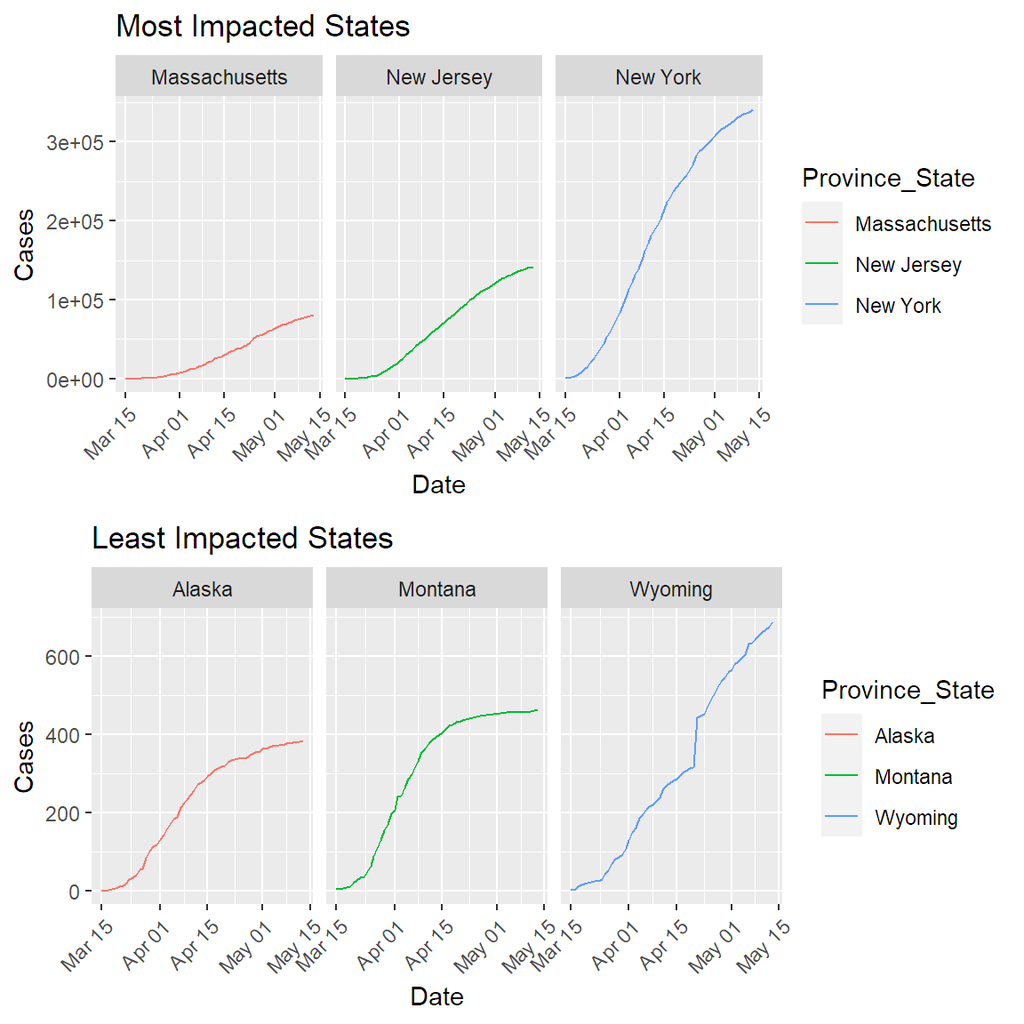

```r
p <- covid.usa.rs %>%
        filter( Province_State %in% covid.usa.impacted.top$Province_State &
                        Date >= strptime("3/15/20","%m/%d/%y") ) %>%
        ggplot( mapping=aes(x=`Date`, y=`Cases`, group=Province_State, color=Province_State)) +
        geom_line() +
        facet_wrap(~Province_State) +
        labs( title = "Most Impacted States") +
        theme(axis.text.x = element_text(angle = 45, hjust=1))
p2 <- covid.usa.rs %>%
        filter( Province_State %in% covid.usa.impacted.bottom$Province_State &
                        Date >= strptime("3/15/20","%m/%d/%y") ) %>%
        ggplot( mapping=aes(x=`Date`, y=`Cases`, group=Province_State, color=Province_State)) +
        geom_line() +
        facet_wrap(~Province_State) +
        labs( title = "Least Impacted States") +
        theme(axis.text.x = element_text(angle = 45, hjust=1))
cowplot::plot_grid(p,p2, nrow = 2, rel_heights=c(0.5,0.5)) + labs(title = "Covid19 Impact")
```

### Does Stay at Home Help?

As is often the case this resembles a logrithmic curve that we are starting to plateu on. For the three most impacted states there isn’t a descernable difference pre or post stay at home order. They all were about the same time, March 24th, 21st, and 22nd respectively. Their inflection point are all around April 7th.

Looking at the least impacted states, on the other hand, we see Alaska and Montana having their inflection point earlier around April 1st, even though they both waited until March 28th for their stay at home orders. Noticibly missing from the list of stay at home orders is Wyoming, and it is noticble that they are experiencing linear growth rather than logrithmic.

### Age, Gender, and Race Impact

```r
agr.agg <- pop.agg %>%
        group_by(NAME) %>%
        summarize(Population =sum(POPESTIMATE2018,na.rm=TRUE) ) %>%
        select(NAME,Population)

agr.daily <- covid.usa.daily %>%
        filter(Province_State %in% pop.agg$NAME) %>%
        mutate( StatePopulation= agr.agg$Population)

agr.join <- left_join(pop.agg, agr.daily, by=c("NAME"="Province_State")) %>%
        mutate( Confirmed.Age = Confirmed * (POPESTIMATE2018/StatePopulation))
agr.join$AGE.GRP = as.factor(agr.join$AGE.GRP)
```

Next we’ll take the population makeup and assume the cases have been distributed evenly throughout each and see if states with a certain group have higher rates.

```r
#str(agr.join)
agr.join
```

```
## # A tibble: 765 x 23
##    NAME  AGE.GRP   SEX POPESTIMATE2018 Country_Region Last_Update           Lat
##    <chr> <fct>   <dbl>           <dbl> <chr>          <dttm>              <dbl>
##  1 Alab~ 0-5         0          735110 US             2020-05-08 02:32:36  32.3
##  2 Alab~ 0-5         1          374326 US             2020-05-08 02:32:36  32.3
##  3 Alab~ 0-5         2          360784 US             2020-05-08 02:32:36  32.3
##  4 Alab~ 19-40       0         2836284 US             2020-05-08 02:32:36  32.3
##  5 Alab~ 19-40       1         1400476 US             2020-05-08 02:32:36  32.3
##  6 Alab~ 19-40       2         1435808 US             2020-05-08 02:32:36  32.3
##  7 Alab~ 41-70       0         3705330 US             2020-05-08 02:32:36  32.3
##  8 Alab~ 41-70       1         1769442 US             2020-05-08 02:32:36  32.3
##  9 Alab~ 41-70       2         1935888 US             2020-05-08 02:32:36  32.3
## 10 Alab~ 6-18        0         1660656 US             2020-05-08 02:32:36  32.3
## # ... with 755 more rows, and 16 more variables: Long_ <dbl>, Confirmed <dbl>,
## #   Deaths <dbl>, Recovered <dbl>, Active <dbl>, FIPS <dbl>,
## #   Incident_Rate <dbl>, People_Tested <dbl>, People_Hospitalized <dbl>,
## #   Mortality_Rate <dbl>, UID <dbl>, ISO3 <chr>, Testing_Rate <dbl>,
## #   Hospitalization_Rate <dbl>, StatePopulation <dbl>, Confirmed.Age <dbl>
```

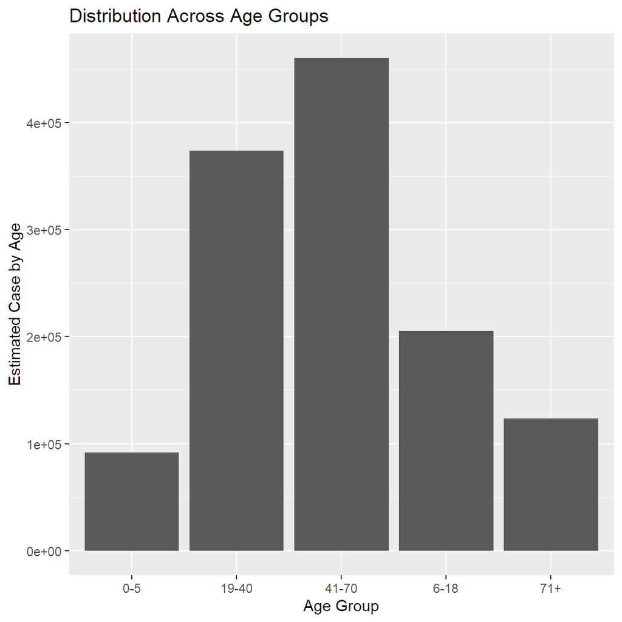

```r
agr.p <- agr.join %>%
        ggplot(mapping=aes(y=Confirmed.Age,x=AGE.GRP, group=AGE.GRP)) +
        geom_col() +
        labs(x="Age Group", y="Estimated Case by Age", title="Distribution Across Age Groups")
agr.p
```

### New York vs. California

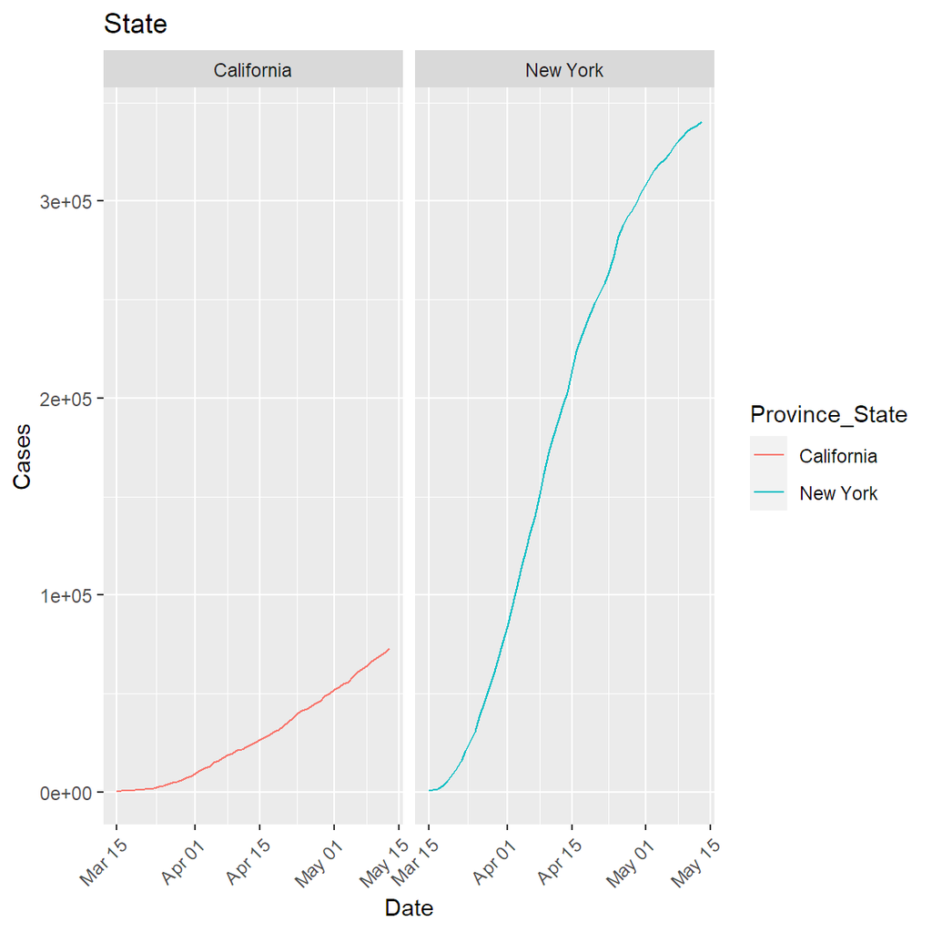

```r
p <- covid.usa.rs %>%
        filter( Province_State %in% c("New York", "California") &
                        Date >= strptime("3/15/20","%m/%d/%y") ) %>%
        ggplot( mapping=aes(x=`Date`, y=`Cases`, group=Province_State, color=Province_State)) +
        geom_line() +
        facet_wrap(~Province_State) +
        labs( title = "State") +
        theme(axis.text.x = element_text(angle = 45, hjust=1))
p
```

```r
pop.agg %>%
        filter( NAME %in% c("New York", "California") ) %>%
        group_by(NAME) %>%
        summarize(Population = sum(POPESTIMATE2018,na.rm=TRUE))
```

```
## # A tibble: 2 x 2
##   NAME       Population
##   <chr>           <dbl>
## 1 California  165070680
## 2 New York     80383748
```

Though California is twice the size of New York by population we see that with California’s earlier action to shut down and stay at home that the curve has been succesfully flatenned as compared to New York which delayed the order at first. This can be seen by the slow growth rate which has not taken on the classic S-curve shape that logrithmic functions would, whereas New York shows this quite distinctly.